# Project_Full_Code_Notebook_EasyVisa

[figure not shown]

Artificial Intelligence and Machine Learning

Ensemble Techniques and Model Tuning

[figure not shown]

Visa Approval Facilitation

# **Problem Statement**

## Context

Business communities in the United States are facing high demand for human resources, but one of the constant challenges is identifying and attracting the right talent, which is perhaps the most important element in remaining competitive. Companies in the United States look for hard-working, talented, and qualified individuals both locally as well as abroad.

The Immigration and Nationality Act (INA) of the US permits foreign workers to come to the United States to work on either a temporary or permanent basis. The act also protects US workers against adverse impacts on their wages or working conditions by ensuring US employers' compliance with statutory requirements when they hire foreign workers to fill workforce shortages. The immigration programs are administered by the Office of Foreign Labor Certification (OFLC).

OFLC processes job certification applications for employers seeking to bring foreign workers into the United States and grants certifications in those cases where employers can demonstrate that there are not sufficient US workers available to perform the work at wages that meet or exceed the wage paid for the occupation in the area of intended employment.

## Objective

In FY 2016, the OFLC processed 775,979 employer applications for 1,699,957 positions for temporary and permanent labor certifications. This was a nine percent increase in the overall number of processed applications from the previous year. The process of reviewing every case is becoming a tedious task as the number of applicants is increasing every year.

The increasing number of applicants every year calls for a Machine Learning based solution that can help in shortlisting the candidates having higher chances of VISA approval. OFLC has hired the firm EasyVisa for data-driven solutions. You as a data scientist at EasyVisa have to analyze the data provided and, with the help of a classification model:

- Facilitate the process of visa approvals.
- Recommend a suitable profile for the applicants for whom the visa should be certified or denied based on the drivers that significantly influence the case status.

## Data Description

The data contains the different attributes of employee and the employer. The detailed data dictionary is given below.

- case_id: ID of each visa application
- continent: Information of continent the employee
- education_of_employee: Information of education of the employee
- has_job_experience: Does the employee has any job experience? Y= Yes; N = No
- requires_job_training: Does the employee require any job training? Y = Yes; N = No
- no_of_employees: Number of employees in the employer's company
- yr_of_estab: Year in which the employer's company was established
- region_of_employment: Information of foreign worker's intended region of employment in the US.
- prevailing_wage: Average wage paid to similarly employed workers in a specific occupation in the area of intended employment. The purpose of the prevailing wage is to ensure that the foreign worker is not underpaid compared to other workers offering the same or similar service in the same area of employment.
- unit_of_wage: Unit of prevailing wage. Values include Hourly, Weekly, Monthly, and Yearly.
- full_time_position: Is the position of work full-time? Y = Full Time Position; N = Part Time Position
- case_status: Flag indicating if the Visa was certified or denied

## Note: This is a sample solution for the project. Projects will NOT be graded on the basis of how well the submission matches this sample solution. Projects will be graded on the basis of the rubric only.

# **Importing necessary libraries**

```python
# Installing the libraries with the specified version.
!pip install numpy==2.0.2 pandas==2.2.2 scikit-learn==1.6.1 matplotlib==3.10.0 seaborn==0.13.2 xgboost==3.0.5 -q --user
```

```
   ━━━━━━━━━━━━━━━━━━━━━━━━━━━━━━━━━━━━━━━━ 94.9/94.9 MB 9.7 MB/s eta 0:00:00
```

**Note**: *After running the above cell, kindly restart the notebook kernel and run all cells sequentially from the start again.*

```python
# To help with reading and manipulation of data
import numpy as np
from numpy import array
import pandas as pd

# To help with data visualization
import matplotlib.pyplot as plt
import seaborn as sns

# To split the data
from sklearn.model_selection import train_test_split
from sklearn.model_selection import StratifiedKFold, cross_val_score
from sklearn.model_selection import RandomizedSearchCV

# To impute missing values
from sklearn.impute import SimpleImputer

# To do one-hot encoding
from sklearn.preprocessing import OneHotEncoder

# To build a decision tree model
from sklearn.tree import DecisionTreeClassifier
from sklearn.ensemble import BaggingClassifier
from sklearn.ensemble import GradientBoostingClassifier
from sklearn.ensemble import RandomForestClassifier
from sklearn.ensemble import AdaBoostClassifier
from xgboost import XGBClassifier


# To get different performance metrics
import sklearn.metrics as metrics
from sklearn.metrics import (
    classification_report,
    confusion_matrix,
    recall_score,
    accuracy_score,
    precision_score,
    f1_score,
)

# To undersample and oversample the data
from imblearn.over_sampling import SMOTE
from imblearn.under_sampling import RandomUnderSampler

# To suppress warnings
import warnings
warnings.filterwarnings("ignore")
```

# **Loading the dataset**

```python
from google.colab import drive
drive.mount('/content/drive')
```

```python
path="/content/drive/MyDrive/Python Course/Project3_EasyVISA/EasyVisa.csv"
df = pd.read_csv(path)
data = df.copy()
```

# **Overview of the Dataset**

- Observations
- Sanity checks

```python
data.head()
```

|  | case_id | continent | education_of_employee | has_job_experience | requires_job_training | no_of_employees | yr_of_estab | region_of_employment | prevailing_wage | unit_of_wage | full_time_position | case_status |
| --- | --- | --- | --- | --- | --- | --- | --- | --- | --- | --- | --- | --- |
| 0 | EZYV01 | Asia | High School | N | N | 14513 | 2007 | West | 592.2029 | Hour | Y | Denied |
| 1 | EZYV02 | Asia | Master's | Y | N | 2412 | 2002 | Northeast | 83425.6500 | Year | Y | Certified |
| 2 | EZYV03 | Asia | Bachelor's | N | Y | 44444 | 2008 | West | 122996.8600 | Year | Y | Denied |
| 3 | EZYV04 | Asia | Bachelor's | N | N | 98 | 1897 | West | 83434.0300 | Year | Y | Denied |
| 4 | EZYV05 | Africa | Master's | Y | N | 1082 | 2005 | South | 149907.3900 | Year | Y | Certified |

```python
data['case_status'].value_counts(1)
```

| case_status | proportion |
| --- | --- |
| Certified | 0.667896 |
| Denied | 0.332104 |

**dtype:** float64

```python
data.info()
```

```
<class 'pandas.core.frame.DataFrame'>
RangeIndex: 25480 entries, 0 to 25479
Data columns (total 12 columns):
 #   Column                 Non-Null Count  Dtype
---  ------                 --------------  -----
 0   case_id                25480 non-null  object
 1   continent              25480 non-null  object
 2   education_of_employee  25480 non-null  object
 3   has_job_experience     25480 non-null  object
 4   requires_job_training  25480 non-null  object
 5   no_of_employees        25480 non-null  int64
 6   yr_of_estab            25480 non-null  int64
 7   region_of_employment   25480 non-null  object
 8   prevailing_wage        25480 non-null  float64
 9   unit_of_wage           25480 non-null  object
 10  full_time_position     25480 non-null  object
 11  case_status            25480 non-null  object
dtypes: float64(1), int64(2), object(9)
memory usage: 2.3+ MB
```

```python
data.isna().sum()
```

|  | 0 |
| --- | --- |
| case_id | 0 |
| continent | 0 |
| education_of_employee | 0 |
| has_job_experience | 0 |
| requires_job_training | 0 |
| no_of_employees | 0 |
| yr_of_estab | 0 |
| region_of_employment | 0 |
| prevailing_wage | 0 |
| unit_of_wage | 0 |
| full_time_position | 0 |
| case_status | 0 |

**dtype:** int64

```python
data.shape
```

```
(25480, 12)
```

```python
data.describe()
```

|  | no_of_employees | yr_of_estab | prevailing_wage |
| --- | --- | --- | --- |
| count | 25480.000000 | 25480.000000 | 25480.000000 |
| mean | 5667.043210 | 1979.409929 | 74455.814592 |
| std | 22877.928848 | 42.366929 | 52815.942327 |
| min | -26.000000 | 1800.000000 | 2.136700 |
| 25% | 1022.000000 | 1976.000000 | 34015.480000 |
| 50% | 2109.000000 | 1997.000000 | 70308.210000 |
| 75% | 3504.000000 | 2005.000000 | 107735.512500 |
| max | 602069.000000 | 2016.000000 | 319210.270000 |

**OBSERVATIONS**

- 66% CERTIFIED
- 33% DENIED
- Many columns have data type as OBJECT
- No missing values
- 25480 rows and 12 columns
- Only 3 variables are numerical rest all are object types.
- Drop `case_id` as "case_id" is unique for each applicant and might not add value to modeling.

# **Exploratory Data Analysis (EDA)**

- EDA is an important part of any project involving data.
- It is important to investigate and understand the data better before building a model with it.
- A few questions have been mentioned below which will help you approach the analysis in the right manner and generate insights from the data.
- A thorough analysis of the data, in addition to the questions mentioned below, should be done.

**Leading Questions**

What is the distribution of visa case statuses (certified vs. denied)?

1. What is the distribution of visa case statuses (certified vs. denied)?
2. How does the education level of employees impact visa approval rates?
3. Is there a significant difference in visa approval rates between employees with and without prior job experience?
4. How does the prevailing wage affect visa approval? Do higher wages lead to higher chances of approval?
5. Do certain regions in the US have higher visa approval rates compared to others?
6. How does the number of employees in a company influence visa approval? Do larger companies have a higher approval rate?
7. Are visa approval rates different across various continents of employees? Which continent has the highest and lowest approval rates?

```python
for feature in data.columns: # Loop through all columns in the dataframe
    if data[feature].dtype == 'object': # Only apply for columns with categorical strings
        data[feature] = pd.Categorical(data[feature])# Replace strings with an integer
data.head(5)
```

|  | case_id | continent | education_of_employee | has_job_experience | requires_job_training | no_of_employees | yr_of_estab | region_of_employment | prevailing_wage | unit_of_wage | full_time_position | case_status |
| --- | --- | --- | --- | --- | --- | --- | --- | --- | --- | --- | --- | --- |
| 0 | EZYV01 | Asia | High School | N | N | 14513 | 2007 | West | 592.2029 | Hour | Y | Denied |
| 1 | EZYV02 | Asia | Master's | Y | N | 2412 | 2002 | Northeast | 83425.6500 | Year | Y | Certified |
| 2 | EZYV03 | Asia | Bachelor's | N | Y | 44444 | 2008 | West | 122996.8600 | Year | Y | Denied |
| 3 | EZYV04 | Asia | Bachelor's | N | N | 98 | 1897 | West | 83434.0300 | Year | Y | Denied |
| 4 | EZYV05 | Africa | Master's | Y | N | 1082 | 2005 | South | 149907.3900 | Year | Y | Certified |

```python
print(data.dtypes)
```

```
case_id                  category
continent                category
education_of_employee    category
has_job_experience       category
requires_job_training    category
no_of_employees             int64
yr_of_estab                 int64
region_of_employment     category
prevailing_wage           float64
unit_of_wage             category
full_time_position       category
case_status              category
dtype: object
```

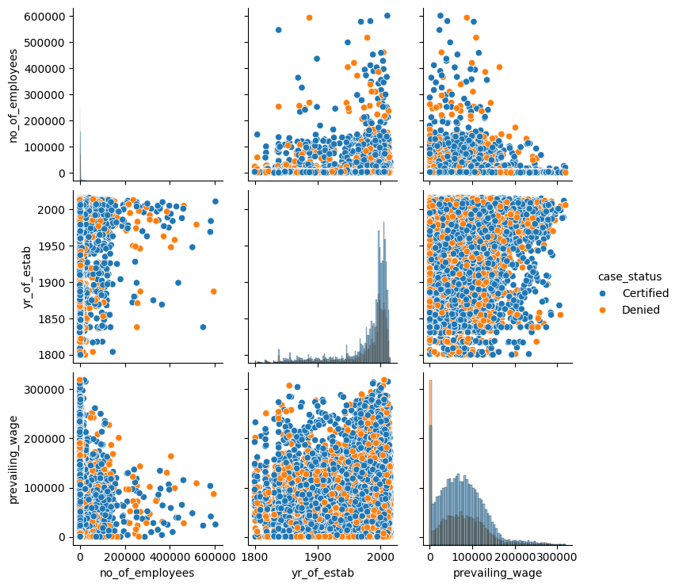

```python
plt.figure(figsize=(17, 21))
sns.pairplot(data, hue = 'case_status' , diag_kind='hist')
plt.show()
```

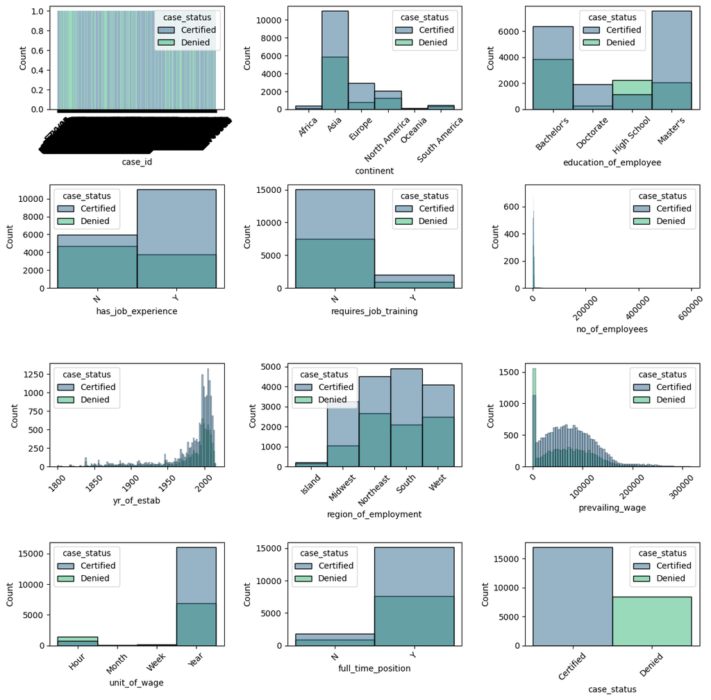

```python
plt.figure(figsize=(12, 14))

for i, feature in enumerate(data.columns):
    plt.subplot(5, 3, i+1)
    sns.histplot(data=data, x=feature, hue='case_status', palette='viridis')
    plt.xticks(rotation=45)

plt.tight_layout();
```

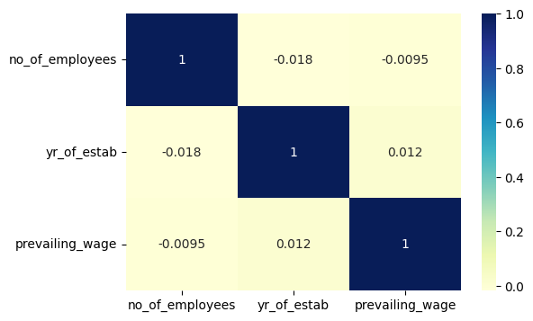

```python
plt.figure(figsize=(6,4))
sns.heatmap(data=data[['no_of_employees','yr_of_estab','prevailing_wage']].corr(), annot=True, cmap='YlGnBu');
plt.yticks(rotation=0)
plt.show()
```

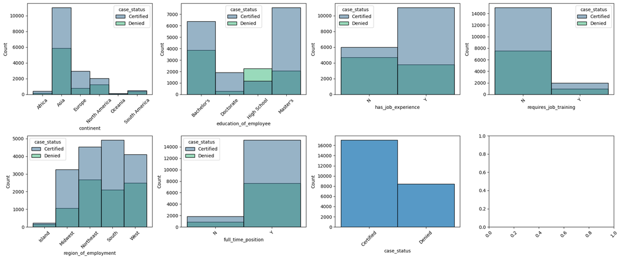

```python
fig, axes = plt.subplots(2, 4, figsize=(19, 8))

sns.histplot(data=data, x='continent', hue='case_status', palette='viridis', ax=axes[0,0])
sns.histplot(data=data, x='education_of_employee', hue='case_status', palette='viridis', ax=axes[0,1])
sns.histplot(data=data, x='has_job_experience', hue='case_status', palette='viridis', ax=axes[0,2])
sns.histplot(data=data, x='requires_job_training', hue='case_status', palette='viridis', ax=axes[0,3])
sns.histplot(data=data, x='region_of_employment', hue='case_status', palette='viridis', ax=axes[1,0])
sns.histplot(data=data, x='full_time_position', hue='case_status', palette='viridis', ax=axes[1,1])
sns.histplot(data=data, x='case_status', palette='viridis', ax=axes[1,2])

for row in axes:
  for ax in row:
    ax.tick_params(axis='x', rotation=45)

plt.tight_layout()
plt.show()
```

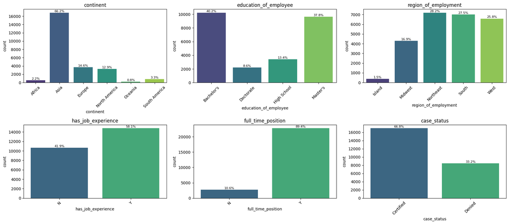

```python
cols = ['continent','education_of_employee','region_of_employment','has_job_experience','full_time_position','case_status']

fig, axes = plt.subplots(2, 3, figsize=(18, 8))
axes = axes.flatten()
total = len(data)

for i, col in enumerate(cols):
    ax = sns.countplot(x=col, data=data, palette='viridis', ax=axes[i])

    for p in ax.patches:
        height = p.get_height()
        percentage = f'{100 * height / total:.1f}%'
        ax.text(p.get_x() + p.get_width()/2,
            height + 2,
            percentage,
            ha='center',
            va='bottom',
            fontsize=8)

    ax.set_title(col)
    ax.tick_params(axis='x', rotation=45)
plt.tight_layout()
plt.show()
```

```python
def histogram_boxplot(data, feature, figsize=(12, 7), kde=False, bins=None):
    """
    Boxplot and histogram combined

    data: dataframe
    feature: dataframe column
    figsize: size of figure (default (12,7))
    kde: whether to the show density curve (default False)
    bins: number of bins for histogram (default None)
    """
    f2, (ax_box2, ax_hist2) = plt.subplots(
        nrows=2,  # Number of rows of the subplot grid= 2
        sharex=True,  # x-axis will be shared among all subplots
        gridspec_kw={"height_ratios": (0.25, 0.75)},
        figsize=figsize,
    )  # creating the 2 subplots
    sns.boxplot(
        data=data, x=feature, ax=ax_box2, showmeans=True, color="violet"
    )  # boxplot will be created and a star will indicate the mean value of the column
    sns.histplot(
        data=data, x=feature, kde=kde, ax=ax_hist2, bins=bins, palette="winter"
    ) if bins else sns.histplot(
        data=data, x=feature, kde=kde, ax=ax_hist2
    )  # For histogram
    ax_hist2.axvline(
        data[feature].mean(), color="green", linestyle="--"
    )  # Add mean to the histogram
    ax_hist2.axvline(
        data[feature].median(), color="black", linestyle="-"
    )  # Add median to the histogram
```

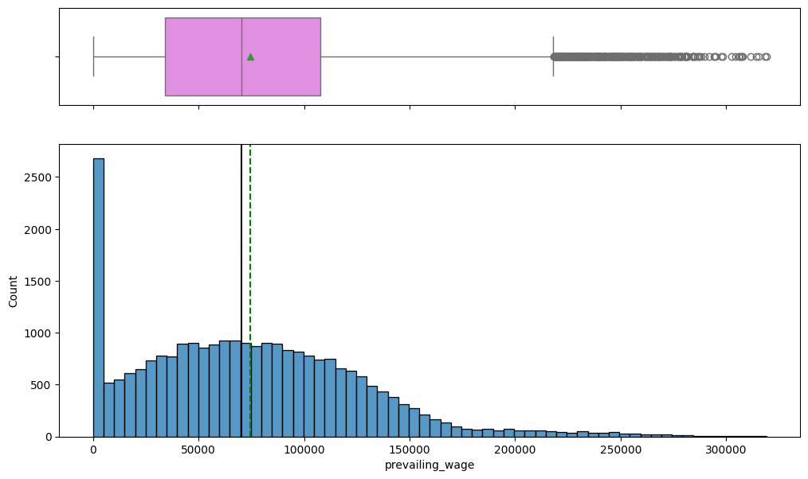

```python
histogram_boxplot(data, "prevailing_wage")
```

```python
### Function to plot distributions


def distribution_plot_wrt_target(data, predictor, target):

    fig, axs = plt.subplots(2, 2, figsize=(12, 10))

    target_uniq = data[target].unique()

    axs[0, 0].set_title("Distribution of target for target=" + str(target_uniq[0]))
    sns.histplot(
        data=data[data[target] == target_uniq[0]],
        x=predictor,
        kde=True,
        ax=axs[0, 0],
        color="teal",
    )

    axs[0, 1].set_title("Distribution of target for target=" + str(target_uniq[1]))
    sns.histplot(
        data=data[data[target] == target_uniq[1]],
        x=predictor,
        kde=True,
        ax=axs[0, 1],
        color="orange",
    )

    axs[1, 0].set_title("Boxplot w.r.t target")
    sns.boxplot(data=data, x=target, y=predictor, ax=axs[1, 0], palette="gist_rainbow")

    axs[1, 1].set_title("Boxplot (without outliers) w.r.t target")
    sns.boxplot(
        data=data,
        x=target,
        y=predictor,
        ax=axs[1, 1],
        showfliers=False,
        palette="gist_rainbow",
    )

    plt.tight_layout()
    plt.show()
```

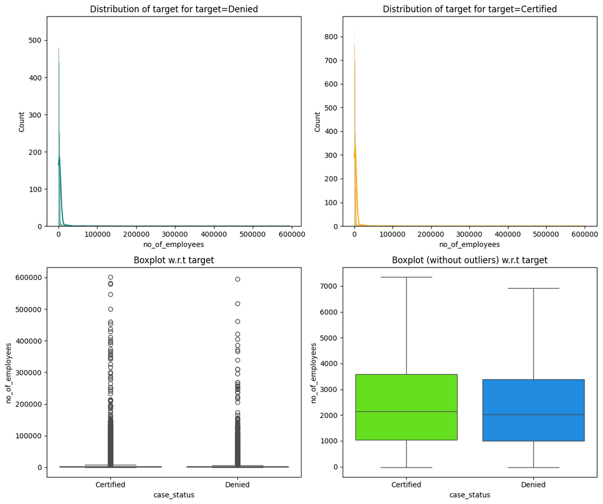

```python
distribution_plot_wrt_target(data, "no_of_employees", "case_status")
```

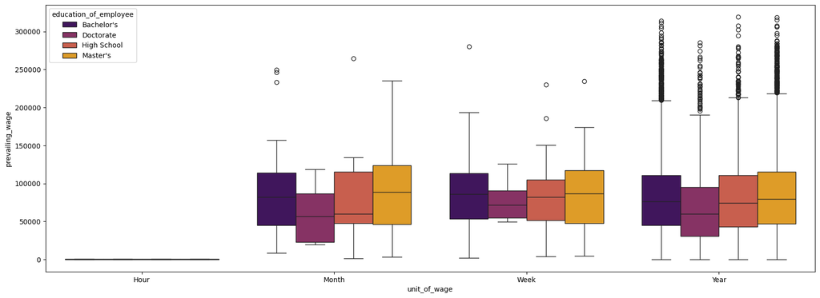

```python
plt.figure(figsize=(20,7))
sns.boxplot(data=data, x='unit_of_wage', y='prevailing_wage', hue='education_of_employee', palette='inferno');
```

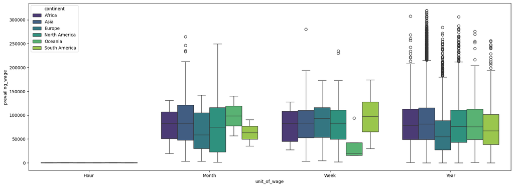

```python
plt.figure(figsize=(20,7))
sns.boxplot(data=data, x='unit_of_wage', y='prevailing_wage', hue='continent', palette='viridis');
```

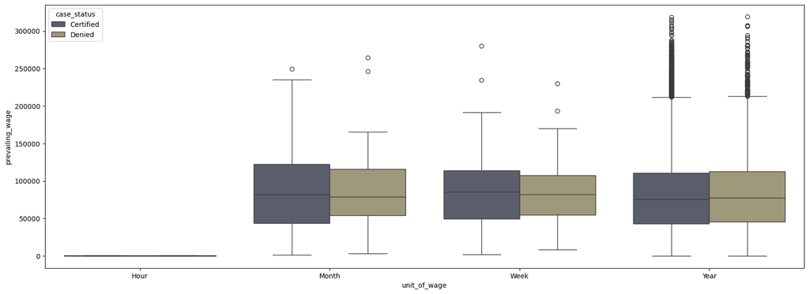

```python
plt.figure(figsize=(20,7))
sns.boxplot(data=data, x='unit_of_wage', y='prevailing_wage', hue='case_status', palette='cividis');
```

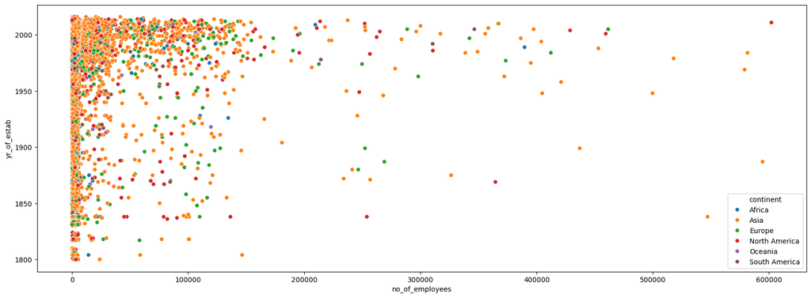

```python
plt.figure(figsize=(20,7))
sns.scatterplot(data=data, x='no_of_employees', y='yr_of_estab', hue='continent')
```

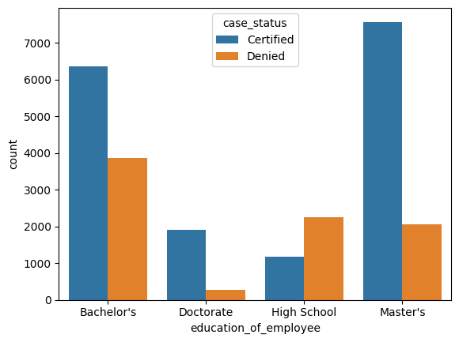

```python
sns.countplot(x='education_of_employee', hue='case_status', data=data)
```

**Observations**

# **Data Pre-processing**

- Missing value treatment (if needed)
- Feature engineering (if needed)
- Outlier detection and treatment (if needed)
- Preparing data for modeling
- Any other preprocessing steps (if needed)

```python
data.isnull().sum()
```

|  | 0 |
| --- | --- |
| case_id | 0 |
| continent | 0 |
| education_of_employee | 0 |
| has_job_experience | 0 |
| requires_job_training | 0 |
| no_of_employees | 0 |
| yr_of_estab | 0 |
| region_of_employment | 0 |
| prevailing_wage | 0 |
| unit_of_wage | 0 |
| full_time_position | 0 |
| case_status | 0 |

**dtype:** int64

```python
data.head()
```

|  | case_id | continent | education_of_employee | has_job_experience | requires_job_training | no_of_employees | yr_of_estab | region_of_employment | prevailing_wage | unit_of_wage | full_time_position | case_status |
| --- | --- | --- | --- | --- | --- | --- | --- | --- | --- | --- | --- | --- |
| 0 | EZYV01 | Asia | High School | N | N | 14513 | 2007 | West | 592.2029 | Hour | Y | Denied |
| 1 | EZYV02 | Asia | Master's | Y | N | 2412 | 2002 | Northeast | 83425.6500 | Year | Y | Certified |
| 2 | EZYV03 | Asia | Bachelor's | N | Y | 44444 | 2008 | West | 122996.8600 | Year | Y | Denied |
| 3 | EZYV04 | Asia | Bachelor's | N | N | 98 | 1897 | West | 83434.0300 | Year | Y | Denied |
| 4 | EZYV05 | Africa | Master's | Y | N | 1082 | 2005 | South | 149907.3900 | Year | Y | Certified |

**Observations**:

*Features:*

Categorical (nominal), One-Hot:

- continent
- education_of_employee
- region_of_employment
- unit_of_wage

Binary, Map:

- has_job_experience
- requires_job_training
- full_time_position

Numerical:

- no_of_employees
- yr_of_estab
- prevailing_wage

Drop (ID): case_id

```python
data.drop(['case_id'], axis=1, inplace=True)
```

```python
print(data.dtypes)
```

```
continent                category
education_of_employee    category
has_job_experience       category
requires_job_training    category
no_of_employees             int64
yr_of_estab                 int64
region_of_employment     category
prevailing_wage           float64
unit_of_wage             category
full_time_position       category
case_status              category
dtype: object
```

```python
#encoding binary features

data['has_job_experience'] = data['has_job_experience'].map({"N": 0, "Y": 1}).astype(int)
data['requires_job_training'] = data['requires_job_training'].map({"N": 0, "Y": 1}).astype(int)
data['full_time_position'] = data['full_time_position'].map({"N": 0, "Y": 1}).astype(int)

data['case_status'] = data['case_status'].map({"Denied": 0, "Certified": 1}).astype(int)
```

```python
print(data.dtypes)
```

```
continent                category
education_of_employee    category
has_job_experience          int64
requires_job_training       int64
no_of_employees             int64
yr_of_estab                 int64
region_of_employment     category
prevailing_wage           float64
unit_of_wage             category
full_time_position          int64
case_status                 int64
dtype: object
```

```python
#Dropping case_status
X = data.drop(['case_status'], axis=1)
y = data['case_status']

# Splitting data into training, validation and test set:
X_temp, X_test, y_temp, y_test = train_test_split(
    X, y, test_size=0.2, random_state=1, stratify=y
)

X_train, X_val, y_train, y_val = train_test_split(
    X_temp, y_temp, test_size=0.25, random_state=1, stratify= y_temp
)

print(X_train.shape, X_val.shape, X_test.shape)
```

```
(15288, 10) (5096, 10) (5096, 10)
```

```python
#One-hot encoding

cat_cols = [
    'continent',
    'education_of_employee',
    'region_of_employment',
    'unit_of_wage'
]

X_train = pd.get_dummies(X_train, columns=cat_cols, drop_first=True)
X_val = pd.get_dummies(X_val, columns=cat_cols, drop_first=True)
X_test = pd.get_dummies(X_test, columns=cat_cols, drop_first=True)
```

```python
X_train, X_val = X_train.align(X_val, join='left', axis=1, fill_value=0)
X_train, X_test = X_train.align(X_test, join='left', axis=1, fill_value=0)
```

```python
print(X_train.shape, X_val.shape, X_test.shape)
```

```
(15288, 21) (5096, 21) (5096, 21)
```

```python
print(X_train.dtypes)
```

```
has_job_experience                     int64
requires_job_training                  int64
no_of_employees                        int64
yr_of_estab                            int64
prevailing_wage                      float64
full_time_position                     int64
continent_Asia                          bool
continent_Europe                        bool
continent_North America                 bool
continent_Oceania                       bool
continent_South America                 bool
education_of_employee_Doctorate         bool
education_of_employee_High School       bool
education_of_employee_Master's          bool
region_of_employment_Midwest            bool
region_of_employment_Northeast          bool
region_of_employment_South              bool
region_of_employment_West               bool
unit_of_wage_Month                      bool
unit_of_wage_Week                       bool
unit_of_wage_Year                       bool
dtype: object
```

**Observations**

# **Model Building**

**What is important to OFLC?**

- Recommend a suitable profile for the applicants for whom the visa should be certified or denied based on the drivers that significantly influence the case status.

**Model can make wrong predictions as:**

1. False Positive (FP): Predicting an applicant would be Certified, but in reality, the applicant would be Denied.
- Problem:
  - The model recommends a weak candidate.
  - Extra review
  - Wasted time
1. False Negative (FN): Predicting an applicant would Denied, but in reality, the applicant would Certified.
- Problem:
  - The model rejects a good candidate, missing a value applicant.
  - Business loss due to a bad decision

**Choosing the metric:**

- The false negative is worse to the business, so we need to minimize it. The metric for this case is RECALL (Recall = TP / (TP + FN)).
- But only minimizing the FN (maximizing recall alone) can be dangerous because the model may classify most everyone as Certified.
- PRECISION is needed to avoid too many bad ones(Precision = TP / (TP + FP)).
- Since F1-Score combines RECALL (catch good candidates) and PRECISION (avoid too many bad ones), **RECALL** and **F1-Score** metrics should be used as metric strategy.

```python
# defining a function to compute different metrics to check performance of a classification model built using sklearn

def model_performance_classification_sklearn(model, predictors, target):
  """
  Function to compute different metrics to check classification model performance

  model: classifier
  predictors: independent variables
  target: dependent variable
  """

  # predicting using the independent variables
  pred = model.predict(predictors)

  acc = accuracy_score(target, pred)
  recall = recall_score(target, pred)
  precision = precision_score(target, pred)
  f1 = f1_score(target, pred)

  # creating a dataframe of metrics
  df_perf = pd.DataFrame(
       {"Accuracy": acc, "Recall": recall, "Precision": precision, "F1": f1,},
        index=[0]
  )

  return df_perf
```

```python
def confusion_matrix_sklearn(model, predictors, target):
  """
  To plot the confusion_matrix with percentages

  model: classifier
  predictors: independent variables
  target: dependent variable
  """

  y_pred = model.predict(predictors)
  cm = confusion_matrix(target, y_pred)
  labels = np.asarray(
      [
          ["{0:0.0f}".format(item) + "\n{0:.2%}".format(item / cm.flatten().sum())]
            for item in cm.flatten()
      ]
  ).reshape(2,2)

  plt.figure(figsize=(6,4))
  sns.heatmap(cm, annot=labels, fmt="")
  plt.ylabel("True Label")
  plt.xlabel("Predicted Label")
```

```python
print(X_train.dtypes)
```

```
has_job_experience                     int64
requires_job_training                  int64
no_of_employees                        int64
yr_of_estab                            int64
prevailing_wage                      float64
full_time_position                     int64
continent_Asia                          bool
continent_Europe                        bool
continent_North America                 bool
continent_Oceania                       bool
continent_South America                 bool
education_of_employee_Doctorate         bool
education_of_employee_High School       bool
education_of_employee_Master's          bool
region_of_employment_Midwest            bool
region_of_employment_Northeast          bool
region_of_employment_South              bool
region_of_employment_West               bool
unit_of_wage_Month                      bool
unit_of_wage_Week                       bool
unit_of_wage_Year                       bool
dtype: object
```

### Model Building - Original Data

```python
models = [] # Empty list to store all the models

# Appending models into the list
models.append(('Bagging', BaggingClassifier(estimator=DecisionTreeClassifier(random_state=1, class_weight='balanced'), random_state=1)))
models.append(('Random forest', RandomForestClassifier(random_state=1, class_weight='balanced')))
models.append(("GBM", GradientBoostingClassifier(random_state=1)))
models.append(('AdaBoost', AdaBoostClassifier(random_state=1)))
models.append(('dtree', DecisionTreeClassifier(random_state=1, class_weight='balanced')))
models.append(('XGB', XGBClassifier(random_state=1, eval_metric='logloss')))

print("\nTraining Performance using Recall metric:\n")
for name, model in models:
    model.fit(X_train, y_train)
    scores = recall_score(y_train, model.predict(X_train))
    print("{}: {}".format(name, scores))

print("\nValidation Performance using Recall metric:\n")
for name, model in models:
    model.fit(X_train, y_train)
    scores_val = recall_score(y_val, model.predict(X_val))
    print("{}: {}".format(name, scores_val))
```

```
Training Performance using Recall metric:

Bagging: 0.9893241919686582
Random forest: 1.0
GBM: 0.8796278158667973
AdaBoost: 0.8882468168462292
dtree: 1.0
XGB: 0.9422135161606269

Validation Performance using Recall metric:

Bagging: 0.7823149236192715
Random forest: 0.8410693301997649
GBM: 0.8742655699177438
AdaBoost: 0.8807285546415982
dtree: 0.7432432432432432
XGB: 0.8522326674500588
```

```python
print("\nTraining and Validation Performance Difference:\n")

for name, model in models:
  model.fit(X_train, y_train)
  scores_train = recall_score(y_train, model.predict(X_train))
  scores_val = recall_score(y_val, model.predict(X_val))
  difference1 = scores_train - scores_val
  print("{}: Training Score: {:.4f}, Validation Score: {:.4f}, Difference: {:.4f}".format(name, scores_train, scores_val, difference1))
```

```
Training and Validation Performance Difference:

Bagging: Training Score: 0.9893, Validation Score: 0.7823, Difference: 0.2070
Random forest: Training Score: 1.0000, Validation Score: 0.8411, Difference: 0.1589
GBM: Training Score: 0.8796, Validation Score: 0.8743, Difference: 0.0054
AdaBoost: Training Score: 0.8882, Validation Score: 0.8807, Difference: 0.0075
dtree: Training Score: 1.0000, Validation Score: 0.7432, Difference: 0.2568
XGB: Training Score: 0.9422, Validation Score: 0.8522, Difference: 0.0900
```

**Observations:**

- XGB, GBM and AdaBoost performed well, they seem very reliable.
- However, other models are overfitting.

# **Model Performance Improvement**

### Model Building - Oversampled Data

```python
print("Before Oversampling, counts of label 'Yes': {}".format(sum(y_train == 1)))
print("Before Oversampling, counts of label 'No': {} \n".format(sum(y_train == 0)))

# Synthetic Minority Over Sampling Technique
sm = SMOTE(
    sampling_strategy=1, k_neighbors=5, random_state=1
)
X_train_over, y_train_over = sm.fit_resample(X_train, y_train)

print("After Oversampling, counts of label 'Yes': {}".format(sum(y_train_over == 1)))
print("After Oversampling, counts of label 'No': {} \n".format(sum(y_train_over == 0)))

print("After Oversampling, the shape of train_X: {}".format(X_train_over.shape))
print("After Oversampling, the shape of train_y: {} \n".format(y_train_over.shape))
```

```
Before Oversampling, counts of label 'Yes': 10210
Before Oversampling, counts of label 'No': 5078

After Oversampling, counts of label 'Yes': 10210
After Oversampling, counts of label 'No': 10210

After Oversampling, the shape of train_X: (20420, 21)
After Oversampling, the shape of train_y: (20420,)
```

```python
models = [] # Empty list to store all the models

# Appending models into the list
models.append(('Bagging', BaggingClassifier(estimator=DecisionTreeClassifier(random_state=1, class_weight='balanced'), random_state=1)))
models.append(('Random forest', RandomForestClassifier(random_state=1, class_weight='balanced')))
models.append(("GBM", GradientBoostingClassifier(random_state=1)))
models.append(('AdaBoost', AdaBoostClassifier(random_state=1)))
models.append(('dtree', DecisionTreeClassifier(random_state=1, class_weight='balanced')))
models.append(('XGB', XGBClassifier(random_state=1, eval_metric='logloss')))

print("\n" "Training Performance:" "\n")
for name, model in models:
    model.fit(X_train_over, y_train_over)
    scores = recall_score(y_train_over, model.predict(X_train_over))
    print("{}: {}".format(name, scores))

print("\n" "Validation Performance:" "\n")
for name, model in models:
    model.fit(X_train_over, y_train_over)
    scores = recall_score(y_val, model.predict(X_val))
    print("{}: {}".format(name, scores))
```

```
Training Performance:

Bagging: 0.9815866797257591
Random forest: 1.0
GBM: 0.8441723800195886
AdaBoost: 0.7925563173359451
dtree: 1.0
XGB: 0.915279138099902

Validation Performance:

Bagging: 0.7511750881316098
Random forest: 0.8084606345475911
GBM: 0.8328437132784959
AdaBoost: 0.782021151586369
dtree: 0.7253231492361927
XGB: 0.8369565217391305
```

```python
print("\nTraining and Validation Performance Difference:\n")

for name, model in models:
    model.fit(X_train_over, y_train_over)
    scores_train = recall_score(y_train_over, model.predict(X_train_over))
    scores_val = recall_score(y_val, model.predict(X_val))
    difference2 = scores_train - scores_val
    print("{}: Training Score: {:.4f}, Validation Score: {:.4f}, Difference: {:.4f}".format(name, scores_train, scores_val, difference2))
```

```
Training and Validation Performance Difference:

Bagging: Training Score: 0.9816, Validation Score: 0.7512, Difference: 0.2304
Random forest: Training Score: 1.0000, Validation Score: 0.8085, Difference: 0.1915
GBM: Training Score: 0.8442, Validation Score: 0.8328, Difference: 0.0113
AdaBoost: Training Score: 0.7926, Validation Score: 0.7820, Difference: 0.0105
dtree: Training Score: 1.0000, Validation Score: 0.7253, Difference: 0.2747
XGB: Training Score: 0.9153, Validation Score: 0.8370, Difference: 0.0783
```

**Observations:**

### Model Building - Undersampled Data

```python
rus = RandomUnderSampler(random_state=1)
X_train_un, y_train_un = rus.fit_resample(X_train, y_train)
```

```python
print("Before Under Sampling, counts of label 'Yes': {}".format(sum(y_train == 1)))
print("Before Under Sampling, counts of label 'No': {} \n".format(sum(y_train == 0)))

print("After Under Sampling, counts of label 'Yes': {}".format(sum(y_train_un == 1)))
print("After Under Sampling, counts of label 'No': {} \n".format(sum(y_train_un == 0)))

print("After Under Sampling, the shape of train_X: {}".format(X_train_un.shape))
print("After Under Sampling, the shape of train_y: {} \n".format(y_train_un.shape))
```

```
Before Under Sampling, counts of label 'Yes': 10210
Before Under Sampling, counts of label 'No': 5078

After Under Sampling, counts of label 'Yes': 5078
After Under Sampling, counts of label 'No': 5078

After Under Sampling, the shape of train_X: (10156, 21)
After Under Sampling, the shape of train_y: (10156,)
```

```python
models = [] # Empty list to store all the models

# Appending models into the list
models.append(('Bagging', BaggingClassifier(estimator=DecisionTreeClassifier(random_state=1, class_weight='balanced'), random_state=1)))
models.append(('Random forest', RandomForestClassifier(random_state=1, class_weight='balanced')))
models.append(("GBM", GradientBoostingClassifier(random_state=1)))
models.append(('AdaBoost', AdaBoostClassifier(random_state=1)))
models.append(('dtree', DecisionTreeClassifier(random_state=1, class_weight='balanced')))
models.append(('XGB', XGBClassifier(random_state=1, eval_metric='logloss')))

print("\n" "Training Performance:" "\n")
for name, model in models:
    model.fit(X_train_un, y_train_un)
    scores = recall_score(y_train_un, model.predict(X_train_un))
    print("{}: {}".format(name, scores))

print("\n" "Validation Performance:" "\n")

for name, model in models:
    model.fit(X_train_un, y_train_un)
    scores = recall_score(y_val, model.predict(X_val))
    print("{}: {}".format(name, scores))
```

```
Training Performance:

Bagging: 0.9679007483261126
Random forest: 1.0
GBM: 0.7483261126427727
AdaBoost: 0.715833005120126
dtree: 1.0
XGB: 0.8794801102796377

Validation Performance:

Bagging: 0.6125146886016452
Random forest: 0.6797884841363102
GBM: 0.7320799059929495
AdaBoost: 0.7159224441833137
dtree: 0.6354289071680376
XGB: 0.6850763807285546
```

```python
print("\nTraining and Validation Performance Difference:\n")

for name, model in models:
    model.fit(X_train_un, y_train_un)
    scores_train = recall_score(y_train_un, model.predict(X_train_un))
    scores_val = recall_score(y_val, model.predict(X_val))
    difference3 = scores_train - scores_val
    print("{}: Training Score: {:.4f}, Validation Score: {:.4f}, Difference: {:.4f}".format(name, scores_train, scores_val, difference3))
```

```
Training and Validation Performance Difference:

Bagging: Training Score: 0.9679, Validation Score: 0.6125, Difference: 0.3554
Random forest: Training Score: 1.0000, Validation Score: 0.6798, Difference: 0.3202
GBM: Training Score: 0.7483, Validation Score: 0.7321, Difference: 0.0162
AdaBoost: Training Score: 0.7158, Validation Score: 0.7159, Difference: -0.0001
dtree: Training Score: 1.0000, Validation Score: 0.6354, Difference: 0.3646
XGB: Training Score: 0.8795, Validation Score: 0.6851, Difference: 0.1944
```

**Observations:**

- Undersampling reduced the model's performance.
- After building 18 models, it's confirmed that XGB, GBM and AdaBoost models, trained on the original dataset, exhibited strong performance on the training and validation original datasets.
- These models will be tuned using original data to get a generalized performance.

### Tuning GradientBoostingClassifier model with the original data

```python
%%time

# defining model
Model = GradientBoostingClassifier(random_state=1)

# Parameter grid to pass in RandomSearchCV
param_grid = {
    "init": [AdaBoostClassifier(random_state=1),DecisionTreeClassifier(random_state=1)],
    "n_estimators": np.arange(50,110,25),
    "learning_rate": [0.01,0.1,0.05],
    "subsample":[0.7,0.9],
    "max_features":[0.5,0.7,1],
}

# Type of scoring used to compare parameter combinations
scorer = metrics.make_scorer(metrics.recall_score)

#Calling RandomizedSearchCV
randomized_cv = RandomizedSearchCV(estimator=Model, param_distributions=param_grid, n_jobs = -1, n_iter=50, scoring=scorer, cv=5, random_state=1)

#Fitting parameters in RandomizedSearchCV
randomized_cv.fit(X_train, y_train)

print("Best parameters are {} with CV score={}:" .format(randomized_cv.best_params_,randomized_cv.best_score_))
```

```
Best parameters are {'subsample': 0.9, 'n_estimators': np.int64(100), 'max_features': 1, 'learning_rate': 0.01, 'init': AdaBoostClassifier(random_state=1)} with CV score=0.93898139079334:
CPU times: user 2.44 s, sys: 229 ms, total: 2.67 s
Wall time: 3min 32s
```

```python
tuned_gbm1 = GradientBoostingClassifier(
    random_state=1,
    subsample=0.9,
    n_estimators=100,
    max_features=1,
    learning_rate=0.01,
    init=AdaBoostClassifier(random_state=1),
)
tuned_gbm1.fit(X_train, y_train)
```

```
GradientBoostingClassifier(init=AdaBoostClassifier(random_state=1),
                           learning_rate=0.01, max_features=1, random_state=1,
                           subsample=0.9)
```

```python
# Checking model's performance on training set

gbm1_train = model_performance_classification_sklearn(
    tuned_gbm1, X_train, y_train
)
gbm1_train
```

|  | Accuracy | Recall | Precision | F1 |
| --- | --- | --- | --- | --- |
| 0 | 0.720958 | 0.941822 | 0.72366 | 0.818453 |

```python
# Checking model's performance on validation set
gbm1_val = model_performance_classification_sklearn(tuned_gbm1, X_val, y_val)
gbm1_val
```

|  | Accuracy | Recall | Precision | F1 |
| --- | --- | --- | --- | --- |
| 0 | 0.720761 | 0.936839 | 0.725267 | 0.817587 |

### Tuning AdaBoostClassifier model with the original data

```python
# defining model
Model = AdaBoostClassifier(random_state=1)

# Parameter grid to pass in RandomSearchCV
param_grid = {
    "n_estimators": np.arange(50,110,25),
    "learning_rate": [0.01,0.1,0.05],
    "estimator": [
        DecisionTreeClassifier(max_depth=2, random_state=1),
        DecisionTreeClassifier(max_depth=3, random_state=1),
    ],
}

# Type of scoring used to compare parameter combinations
scorer = metrics.make_scorer(metrics.recall_score)

#Calling RandomizedSearchCV
randomized_cv = RandomizedSearchCV(estimator=Model, param_distributions=param_grid, n_jobs = -1, n_iter=50, scoring=scorer, cv=5, random_state=1)

#Fitting parameters in RandomizedSearchCV
randomized_cv.fit(X_train, y_train)

print("Best parameters are {} with CV score={}:" .format(randomized_cv.best_params_,randomized_cv.best_score_))
```

```
Best parameters are {'n_estimators': np.int64(50), 'learning_rate': 0.01, 'estimator': DecisionTreeClassifier(max_depth=3, random_state=1)} with CV score=0.9288932419196865:
```

```python
tuned_adb = AdaBoostClassifier(
    random_state=1,
    n_estimators=50,
    learning_rate=0.01,
    estimator=DecisionTreeClassifier(max_depth=3, random_state=1),
)
tuned_adb.fit(X_train, y_train)
```

```
AdaBoostClassifier(estimator=DecisionTreeClassifier(max_depth=3,
                                                    random_state=1),
                   learning_rate=0.01, random_state=1)
```

```python
# Checking model's performance on training set
adb_train = model_performance_classification_sklearn(tuned_adb, X_train, y_train)
adb_train
```

|  | Accuracy | Recall | Precision | F1 |
| --- | --- | --- | --- | --- |
| 0 | 0.729003 | 0.924682 | 0.736715 | 0.820065 |

```python
# Checking model's performance on validation set
adb_val = model_performance_classification_sklearn(tuned_adb, X_val, y_val)
adb_val
```

|  | Accuracy | Recall | Precision | F1 |
| --- | --- | --- | --- | --- |
| 0 | 0.73489 | 0.925088 | 0.741814 | 0.823376 |

### Tuning XGBClassifier model with the original data

```python
%%time

# defining model
Model = XGBClassifier(random_state=1,eval_metric='logloss')

# Parameter grid to pass in RandomSearchCV
param_grid={'n_estimators':np.arange(50,110,25),
            'scale_pos_weight':[1,2,5],
            'learning_rate':[0.01,0.1,0.05],
            'gamma':[1,3],
            'subsample':[0.7,0.9]
}

# Type of scoring used to compare parameter combinations
scorer = metrics.make_scorer(metrics.recall_score)

#Calling RandomizedSearchCV
randomized_cv = RandomizedSearchCV(estimator=Model, param_distributions=param_grid, n_jobs = -1, n_iter=50, scoring=scorer, cv=5, random_state=1)

#Fitting parameters in RandomizedSearchCV
randomized_cv.fit(X_train, y_train)

print("Best parameters are {} with CV score={}:" .format(randomized_cv.best_params_,randomized_cv.best_score_))
```

```
Best parameters are {'subsample': 0.7, 'scale_pos_weight': 5, 'n_estimators': np.int64(50), 'learning_rate': 0.01, 'gamma': 3} with CV score=1.0:
CPU times: user 1.36 s, sys: 150 ms, total: 1.51 s
Wall time: 50.6 s
```

```python
tuned_xgb1 = XGBClassifier(
    random_state=1,
    subsample=0.7,
    n_estimators=50,
    learning_rate=0.01,
    gamma=3,
    scale_pos_weight= 5
)
tuned_xgb1.fit(X_train, y_train)
```

```
XGBClassifier(base_score=None, booster=None, callbacks=None,
              colsample_bylevel=None, colsample_bynode=None,
              colsample_bytree=None, device=None, early_stopping_rounds=None,
              enable_categorical=False, eval_metric=None, feature_types=None,
              feature_weights=None, gamma=3, grow_policy=None,
              importance_type=None, interaction_constraints=None,
              learning_rate=0.01, max_bin=None, max_cat_threshold=None,
              max_cat_to_onehot=None, max_delta_step=None, max_depth=None,
              max_leaves=None, min_child_weight=None, missing=nan,
              monotone_constraints=None, multi_strategy=None, n_estimators=50,
              n_jobs=None, num_parallel_tree=None, ...)
```

```python
# Checking model's performance on training set

xgb1_train = model_performance_classification_sklearn(
    tuned_xgb1, X_train, y_train
)
xgb1_train
```

|  | Accuracy | Recall | Precision | F1 |
| --- | --- | --- | --- | --- |
| 0 | 0.667844 | 1.0 | 0.667844 | 0.800847 |

```python
# Checking model's performance on validation set
xgb1_val = model_performance_classification_sklearn(tuned_xgb1, X_val, y_val)
xgb1_val
```

|  | Accuracy | Recall | Precision | F1 |
| --- | --- | --- | --- | --- |
| 0 | 0.667975 | 1.0 | 0.667975 | 0.800941 |

### Tuning GradientBoostingClassifier model with the Oversampled data

```python
%%time

#defining model
Model = GradientBoostingClassifier(random_state=1)

#Parameter grid to pass in RandomSearchCV
param_grid = {
    "init": [AdaBoostClassifier(random_state=1),DecisionTreeClassifier(random_state=1)],
    "n_estimators": np.arange(50,110,25),
    "learning_rate": [0.01,0.1,0.05],
    "subsample":[0.7,0.9],
    "max_features":[0.5,0.7,1],
}

# Type of scoring used to compare parameter combinations
scorer = metrics.make_scorer(metrics.recall_score)

#Calling RandomizedSearchCV
randomized_cv = RandomizedSearchCV(estimator=Model, param_distributions=param_grid, n_iter=50, scoring=scorer, cv=5, random_state=1, n_jobs = -1)

#Fitting parameters in RandomizedSearchCV
randomized_cv.fit(X_train_over, y_train_over)

print("Best parameters are {} with CV score={}:" .format(randomized_cv.best_params_,randomized_cv.best_score_))
```

```
Best parameters are {'subsample': 0.9, 'n_estimators': np.int64(75), 'max_features': 0.7, 'learning_rate': 0.1, 'init': AdaBoostClassifier(random_state=1)} with CV score=0.8352595494613123:
CPU times: user 5.11 s, sys: 240 ms, total: 5.35 s
Wall time: 4min 29s
```

```python
tuned_gbm2 = GradientBoostingClassifier(
    random_state=1,
    subsample=0.9,
    n_estimators=75,
    max_features=0.7,
    learning_rate=0.1,
    init=AdaBoostClassifier(random_state=1),
)
tuned_gbm2.fit(X_train_over, y_train_over)
```

```
GradientBoostingClassifier(init=AdaBoostClassifier(random_state=1),
                           max_features=0.7, n_estimators=75, random_state=1,
                           subsample=0.9)
```

```python
# Checking model's performance on training set
gbm2_train = model_performance_classification_sklearn(tuned_gbm2, X_train_over, y_train_over)
gbm2_train
```

|  | Accuracy | Recall | Precision | F1 |
| --- | --- | --- | --- | --- |
| 0 | 0.800784 | 0.837708 | 0.780099 | 0.807878 |

```python
# Checking model's performance on validation set
gbm2_val = model_performance_classification_sklearn(tuned_gbm2, X_val, y_val)
gbm2_val
```

|  | Accuracy | Recall | Precision | F1 |
| --- | --- | --- | --- | --- |
| 0 | 0.741562 | 0.825499 | 0.795358 | 0.810148 |

### Tuning AdaBoostClassifier model with the Oversampled data

```python
%%time

# defining model
Model = AdaBoostClassifier(random_state=1)

# Parameter grid to pass in RandomSearchCV
param_grid = {
    "n_estimators": np.arange(50,110,25),
    "learning_rate": [0.01,0.1,0.05],
    "estimator": [
        DecisionTreeClassifier(max_depth=2, random_state=1),
        DecisionTreeClassifier(max_depth=3, random_state=1),
    ],
}

# Type of scoring used to compare parameter combinations
scorer = metrics.make_scorer(metrics.recall_score)

#Calling RandomizedSearchCV
randomized_cv = RandomizedSearchCV(estimator=Model, param_distributions=param_grid, n_jobs = -1, n_iter=50, scoring=scorer, cv=5, random_state=1)

#Fitting parameters in RandomizedSearchCV
randomized_cv.fit(X_train_over, y_train_over)

print("Best parameters are {} with CV score={}:" .format(randomized_cv.best_params_,randomized_cv.best_score_))
```

```
Best parameters are {'n_estimators': np.int64(100), 'learning_rate': 0.1, 'estimator': DecisionTreeClassifier(max_depth=3, random_state=1)} with CV score=0.8215475024485798:
CPU times: user 4.22 s, sys: 125 ms, total: 4.35 s
Wall time: 2min 35s
```

```python
tuned_adb2 = AdaBoostClassifier(
    random_state=1,
    n_estimators=100,
    learning_rate=0.1,
    estimator=DecisionTreeClassifier(max_depth=3, random_state=1),
)
tuned_adb2.fit(X_train_over, y_train_over)
```

```
AdaBoostClassifier(estimator=DecisionTreeClassifier(max_depth=3,
                                                    random_state=1),
                   learning_rate=0.1, n_estimators=100, random_state=1)
```

```python
# Checking model's performance on training set
adb2_train = model_performance_classification_sklearn(tuned_adb2, X_train, y_train)
adb2_train
```

|  | Accuracy | Recall | Precision | F1 |
| --- | --- | --- | --- | --- |
| 0 | 0.738291 | 0.815965 | 0.796996 | 0.806369 |

```python
# Checking model's performance on validation set
adb2_val = model_performance_classification_sklearn(tuned_adb2, X_val, y_val)
adb2_val
```

|  | Accuracy | Recall | Precision | F1 |
| --- | --- | --- | --- | --- |
| 0 | 0.73646 | 0.808754 | 0.799129 | 0.803913 |

### Tuning XGBClassifier model with the Oversampled data

```python
%%time

# defining model
Model = XGBClassifier(random_state=1,eval_metric='logloss')

# Parameter grid to pass in RandomSearchCV
param_grid={'n_estimators':np.arange(50,110,25),
            'scale_pos_weight':[1,2,5],
            'learning_rate':[0.01,0.1,0.05],
            'gamma':[1,3],
            'subsample':[0.7,0.9]
}

# Type of scoring used to compare parameter combinations
scorer = metrics.make_scorer(metrics.recall_score)

#Calling RandomizedSearchCV
randomized_cv = RandomizedSearchCV(estimator=Model, param_distributions=param_grid, n_jobs = -1, n_iter=50, scoring=scorer, cv=5, random_state=1)

#Fitting parameters in RandomizedSearchCV
randomized_cv.fit(X_train_over, y_train_over)

print("Best parameters are {} with CV score={}:" .format(randomized_cv.best_params_,randomized_cv.best_score_))
```

```
Best parameters are {'subsample': 0.7, 'scale_pos_weight': 5, 'n_estimators': np.int64(50), 'learning_rate': 0.01, 'gamma': 3} with CV score=1.0:
CPU times: user 1.58 s, sys: 129 ms, total: 1.71 s
Wall time: 1min 2s
```

```python
tuned_xgb2 = XGBClassifier(
    random_state=1,
    subsample=0.7,
    n_estimators=50,
    learning_rate=0.01,
    gamma=3,
    scale_pos_weight= 5
)
tuned_xgb2.fit(X_train_over, y_train_over)
```

```
XGBClassifier(base_score=None, booster=None, callbacks=None,
              colsample_bylevel=None, colsample_bynode=None,
              colsample_bytree=None, device=None, early_stopping_rounds=None,
              enable_categorical=False, eval_metric=None, feature_types=None,
              feature_weights=None, gamma=3, grow_policy=None,
              importance_type=None, interaction_constraints=None,
              learning_rate=0.01, max_bin=None, max_cat_threshold=None,
              max_cat_to_onehot=None, max_delta_step=None, max_depth=None,
              max_leaves=None, min_child_weight=None, missing=nan,
              monotone_constraints=None, multi_strategy=None, n_estimators=50,
              n_jobs=None, num_parallel_tree=None, ...)
```

```python
# Checking model's performance on training set

xgb2_train = model_performance_classification_sklearn(
    tuned_xgb2, X_train_over, y_train_over
)
xgb2_train
```

|  | Accuracy | Recall | Precision | F1 |
| --- | --- | --- | --- | --- |
| 0 | 0.548678 | 1.0 | 0.525584 | 0.689027 |

```python
# Checking model's performance on validation set
xgb2_val = model_performance_classification_sklearn(tuned_xgb2, X_val, y_val)
xgb2_val
```

|  | Accuracy | Recall | Precision | F1 |
| --- | --- | --- | --- | --- |
| 0 | 0.667975 | 1.0 | 0.667975 | 0.800941 |

### Tuning GradientBoostingClassifier model with the Undersampled data

```python
%%time

#defining model
Model = GradientBoostingClassifier(random_state=1)

#Parameter grid to pass in RandomSearchCV
param_grid = {
    "init": [AdaBoostClassifier(random_state=1),DecisionTreeClassifier(random_state=1)],
    "n_estimators": np.arange(50,110,25),
    "learning_rate": [0.01,0.1,0.05],
    "subsample":[0.7,0.9],
    "max_features":[0.5,0.7,1],
}

# Type of scoring used to compare parameter combinations
scorer = metrics.make_scorer(metrics.recall_score)

#Calling RandomizedSearchCV
randomized_cv = RandomizedSearchCV(estimator=Model, param_distributions=param_grid, n_iter=50, scoring=scorer, cv=5, random_state=1, n_jobs = -1)

#Fitting parameters in RandomizedSearchCV
randomized_cv.fit(X_train_un, y_train_un)

print("Best parameters are {} with CV score={}:" .format(randomized_cv.best_params_,randomized_cv.best_score_))
```

```
Best parameters are {'subsample': 0.7, 'n_estimators': np.int64(75), 'max_features': 0.5, 'learning_rate': 0.01, 'init': AdaBoostClassifier(random_state=1)} with CV score=0.7461615142934719:
CPU times: user 2.23 s, sys: 141 ms, total: 2.37 s
Wall time: 2min 29s
```

```python
tuned_gbm3 = GradientBoostingClassifier(
    random_state=1,
    subsample=0.7,
    n_estimators=75,
    max_features=0.5,
    learning_rate=0.01,
    init=AdaBoostClassifier(random_state=1),
)
tuned_gbm3.fit(X_train_un, y_train_un)
```

```
GradientBoostingClassifier(init=AdaBoostClassifier(random_state=1),
                           learning_rate=0.01, max_features=0.5,
                           n_estimators=75, random_state=1, subsample=0.7)
```

```python
# Checking model's performance on training set
gbm3_train = model_performance_classification_sklearn(tuned_gbm3, X_train_un, y_train_un)
gbm3_train
```

|  | Accuracy | Recall | Precision | F1 |
| --- | --- | --- | --- | --- |
| 0 | 0.703722 | 0.751871 | 0.685827 | 0.717332 |

```python
# Checking model's performance on validation set
gbm3_val = model_performance_classification_sklearn(tuned_gbm3, X_val, y_val)
gbm3_val
```

|  | Accuracy | Recall | Precision | F1 |
| --- | --- | --- | --- | --- |
| 0 | 0.722724 | 0.74765 | 0.821233 | 0.782716 |

### Tuning AdaBoostClassifier model with the Undersampled data

```python
%%time

# defining model
Model = AdaBoostClassifier(random_state=1)

# Parameter grid to pass in RandomSearchCV
param_grid = {
    "n_estimators": np.arange(50,110,25),
    "learning_rate": [0.01,0.1,0.05],
    "estimator": [
        DecisionTreeClassifier(max_depth=2, random_state=1),
        DecisionTreeClassifier(max_depth=3, random_state=1),
    ],
}

# Type of scoring used to compare parameter combinations
scorer = metrics.make_scorer(metrics.recall_score)

#Calling RandomizedSearchCV
randomized_cv = RandomizedSearchCV(estimator=Model, param_distributions=param_grid, n_jobs = -1, n_iter=50, scoring=scorer, cv=5, random_state=1)

#Fitting parameters in RandomizedSearchCV
randomized_cv.fit(X_train_un, y_train_un)

print("Best parameters are {} with CV score={}:" .format(randomized_cv.best_params_,randomized_cv.best_score_))
```

```
Best parameters are {'n_estimators': np.int64(75), 'learning_rate': 0.01, 'estimator': DecisionTreeClassifier(max_depth=2, random_state=1)} with CV score=0.7815984639851052:
CPU times: user 1.44 s, sys: 69.9 ms, total: 1.51 s
Wall time: 1min 21s
```

```python
tuned_adb3 = AdaBoostClassifier(
    random_state=1,
    n_estimators=75,
    learning_rate=0.01,
    estimator=DecisionTreeClassifier(max_depth=2, random_state=1),
)
tuned_adb3.fit(X_train_un, y_train_un)
```

```
AdaBoostClassifier(estimator=DecisionTreeClassifier(max_depth=2,
                                                    random_state=1),
                   learning_rate=0.01, n_estimators=75, random_state=1)
```

```python
# Checking model's performance on training set
adb3_train = model_performance_classification_sklearn(tuned_adb3, X_train, y_train)
adb3_train
```

|  | Accuracy | Recall | Precision | F1 |
| --- | --- | --- | --- | --- |
| 0 | 0.728676 | 0.89001 | 0.750248 | 0.814174 |

```python
# Checking model's performance on validation set
adb3_val = model_performance_classification_sklearn(tuned_adb3, X_val, y_val)
adb3_val
```

|  | Accuracy | Recall | Precision | F1 |
| --- | --- | --- | --- | --- |
| 0 | 0.736264 | 0.891892 | 0.75673 | 0.81877 |

### Tuning XGBClassifier model with the Undersampled data

```python
%%time

# defining model
Model = XGBClassifier(random_state=1,eval_metric='logloss')

# Parameter grid to pass in RandomSearchCV
param_grid={'n_estimators':np.arange(50,110,25),
            'scale_pos_weight':[1,2,5],
            'learning_rate':[0.01,0.1,0.05],
            'gamma':[1,3],
            'subsample':[0.7,0.9]
}

# Type of scoring used to compare parameter combinations
scorer = metrics.make_scorer(metrics.recall_score)

#Calling RandomizedSearchCV
randomized_cv = RandomizedSearchCV(estimator=Model, param_distributions=param_grid, n_jobs = -1, n_iter=50, scoring=scorer, cv=5, random_state=1)

#Fitting parameters in RandomizedSearchCV
randomized_cv.fit(X_train_un, y_train_un)

print("Best parameters are {} with CV score={}:" .format(randomized_cv.best_params_,randomized_cv.best_score_))
```

```
Best parameters are {'subsample': 0.7, 'scale_pos_weight': 5, 'n_estimators': np.int64(50), 'learning_rate': 0.01, 'gamma': 3} with CV score=1.0:
CPU times: user 1.49 s, sys: 102 ms, total: 1.6 s
Wall time: 51.2 s
```

```python
tuned_xgb3 = XGBClassifier(
    random_state=1,
    subsample=0.7,
    n_estimators=50,
    learning_rate=0.01,
    gamma=3,
    scale_pos_weight= 5
)
tuned_xgb3.fit(X_train_un, y_train_un)
```

```
XGBClassifier(base_score=None, booster=None, callbacks=None,
              colsample_bylevel=None, colsample_bynode=None,
              colsample_bytree=None, device=None, early_stopping_rounds=None,
              enable_categorical=False, eval_metric=None, feature_types=None,
              feature_weights=None, gamma=3, grow_policy=None,
              importance_type=None, interaction_constraints=None,
              learning_rate=0.01, max_bin=None, max_cat_threshold=None,
              max_cat_to_onehot=None, max_delta_step=None, max_depth=None,
              max_leaves=None, min_child_weight=None, missing=nan,
              monotone_constraints=None, multi_strategy=None, n_estimators=50,
              n_jobs=None, num_parallel_tree=None, ...)
```

```python
# Checking model's performance on training set

xgb3_train = model_performance_classification_sklearn(
    tuned_xgb3, X_train_un, y_train_un
)
xgb3_train
```

|  | Accuracy | Recall | Precision | F1 |
| --- | --- | --- | --- | --- |
| 0 | 0.5 | 1.0 | 0.5 | 0.666667 |

```python
# Checking model's performance on validation set
xgb3_val = model_performance_classification_sklearn(tuned_xgb3, X_val, y_val)
xgb3_val
```

|  | Accuracy | Recall | Precision | F1 |
| --- | --- | --- | --- | --- |
| 0 | 0.667975 | 1.0 | 0.667975 | 0.800941 |

## **Note**

1. Sample parameter grids have been provided to do necessary hyperparameter tuning. These sample grids are expected to provide a balance between model performance improvement and execution time. One can extend/reduce the parameter grid based on execution time and system configuration.
   - Please note that if the parameter grid is extended to improve the model performance further, the execution time will increase
2. The models chosen in this notebook are based on test runs. One can update the best models as obtained upon code execution and tune them for best performance.
- For Gradient Boosting:

```
param_grid = {
    "init": [AdaBoostClassifier(random_state=1),DecisionTreeClassifier(random_state=1)],
    "n_estimators": np.arange(50,110,25),
    "learning_rate": [0.01,0.1,0.05],
    "subsample":[0.7,0.9],
    "max_features":[0.5,0.7,1],
}
```

- For Adaboost:

```
param_grid = {
    "n_estimators": np.arange(50,110,25),
    "learning_rate": [0.01,0.1,0.05],
    "base_estimator": [
        DecisionTreeClassifier(max_depth=2, random_state=1),
        DecisionTreeClassifier(max_depth=3, random_state=1),
    ],
}
```

- For Bagging Classifier:

```
param_grid = {
    'max_samples': [0.8,0.9,1],
    'max_features': [0.7,0.8,0.9],
    'n_estimators' : [30,50,70],
}
```

- For Random Forest:

```
param_grid = {
    "n_estimators": [50,110,25],
    "min_samples_leaf": np.arange(1, 4),
    "max_features": [np.arange(0.3, 0.6, 0.1),'sqrt'],
    "max_samples": np.arange(0.4, 0.7, 0.1)
}
```

- For Decision Trees:

```
param_grid = {
    'max_depth': np.arange(2,6),
    'min_samples_leaf': [1, 4, 7],
    'max_leaf_nodes' : [10, 15],
    'min_impurity_decrease': [0.0001,0.001]
}
```

- For XGBoost:

```
param_grid={'n_estimators':np.arange(50,110,25),
            'scale_pos_weight':[1,2,5],
            'learning_rate':[0.01,0.1,0.05],
            'gamma':[1,3],
            'subsample':[0.7,0.9]
}
```

# **Model Comparison and Final Model Selection**

```python
# training performance comparison

models_train_comp_df = pd.concat(
    [
        gbm1_train.T,
        adb_train.T,
        xgb1_train.T,
        gbm2_train.T,
        adb2_train.T,
        xgb2_train.T,
        gbm3_train.T,
        adb3_train.T,
        xgb3_train.T,
    ],
    axis=1,
)
models_train_comp_df.columns = [
    "Gradient boosting trained with original data",
    "AdaBoost trained with original data",
    "XGB trained with original data",
    "Gradient boosting trained with Oversampled data",
    "AdaBoost trained with Oversampled data",
    "XGB trained with Oversampled data",
    "Gradient boosting trained with Undersampled data",
    "AdaBoost trained with Undersampled data",
    "XGB trained with Undersampled data",
]
print("Training performance comparison:")
models_train_comp_df
```

```
Training performance comparison:
```

|  | Gradient boosting trained with original data | AdaBoost trained with original data | XGB trained with original data | Gradient boosting trained with Oversampled data | AdaBoost trained with Oversampled data | XGB trained with Oversampled data | Gradient boosting trained with Undersampled data | AdaBoost trained with Undersampled data | XGB trained with Undersampled data |
| --- | --- | --- | --- | --- | --- | --- | --- | --- | --- |
| Accuracy | 0.720958 | 0.729003 | 0.667844 | 0.800784 | 0.738291 | 0.548678 | 0.703722 | 0.728676 | 0.500000 |
| Recall | 0.941822 | 0.924682 | 1.000000 | 0.837708 | 0.815965 | 1.000000 | 0.751871 | 0.890010 | 1.000000 |
| Precision | 0.723660 | 0.736715 | 0.667844 | 0.780099 | 0.796996 | 0.525584 | 0.685827 | 0.750248 | 0.500000 |
| F1 | 0.818453 | 0.820065 | 0.800847 | 0.807878 | 0.806369 | 0.689027 | 0.717332 | 0.814174 | 0.666667 |

```python
# Validation performance comparison

models_train_comp_df = pd.concat(
    [
        gbm1_val.T,
        adb_val.T,
        xgb1_val.T,
        gbm2_val.T,
        adb2_val.T,
        xgb2_val.T,
        gbm3_val.T,
        adb3_val.T,
        xgb3_val.T,
    ], axis=1,
)
models_train_comp_df.columns = [
    "Gradient boosting trained with original data",
    "AdaBoost trained with original data",
    "XGB trained with original data",
    "Gradient boosting trained with Oversampled data",
    "AdaBoost trained with Oversampled data",
    "XGB trained with Oversampled data",
    "Gradient boosting trained with Undersampled data",
    "AdaBoost trained with Undersampled data",
    "XGB trained with Undersampled data",
]
print("Validation performance comparison:")
models_train_comp_df
```

```
Validation performance comparison:
```

|  | Gradient boosting trained with original data | AdaBoost trained with original data | XGB trained with original data | Gradient boosting trained with Oversampled data | AdaBoost trained with Oversampled data | XGB trained with Oversampled data | Gradient boosting trained with Undersampled data | AdaBoost trained with Undersampled data | XGB trained with Undersampled data |
| --- | --- | --- | --- | --- | --- | --- | --- | --- | --- |
| Accuracy | 0.720761 | 0.734890 | 0.667975 | 0.741562 | 0.736460 | 0.667975 | 0.722724 | 0.736264 | 0.667975 |
| Recall | 0.936839 | 0.925088 | 1.000000 | 0.825499 | 0.808754 | 1.000000 | 0.747650 | 0.891892 | 1.000000 |
| Precision | 0.725267 | 0.741814 | 0.667975 | 0.795358 | 0.799129 | 0.667975 | 0.821233 | 0.756730 | 0.667975 |
| F1 | 0.817587 | 0.823376 | 0.800941 | 0.810148 | 0.803913 | 0.800941 | 0.782716 | 0.818770 | 0.800941 |

**Observations:**

```python
# Let's check the performance on test set
gbm1_test = model_performance_classification_sklearn(tuned_gbm1, X_test, y_test)
gbm1_test
```

|  | Accuracy | Recall | Precision | F1 |
| --- | --- | --- | --- | --- |
| 0 | 0.711146 | 0.935076 | 0.717862 | 0.812197 |

```
0.9350763807285546
```

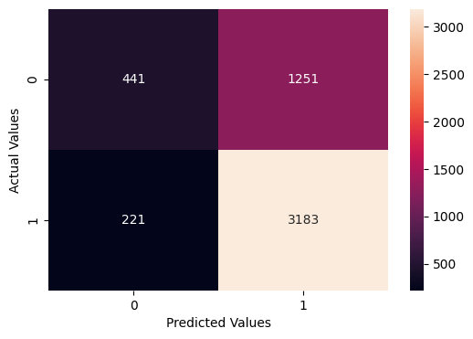

```python
# Now we have identified the best model, let's check its performance on test set
print(recall_score(y_test, tuned_gbm1.predict(X_test)))

cm = confusion_matrix(y_test, tuned_gbm1.predict(X_test))
plt.figure(figsize=(6, 4))
sns.heatmap(cm, annot=True, fmt="g")
plt.xlabel("Predicted Values")
plt.ylabel("Actual Values")
plt.show()
```

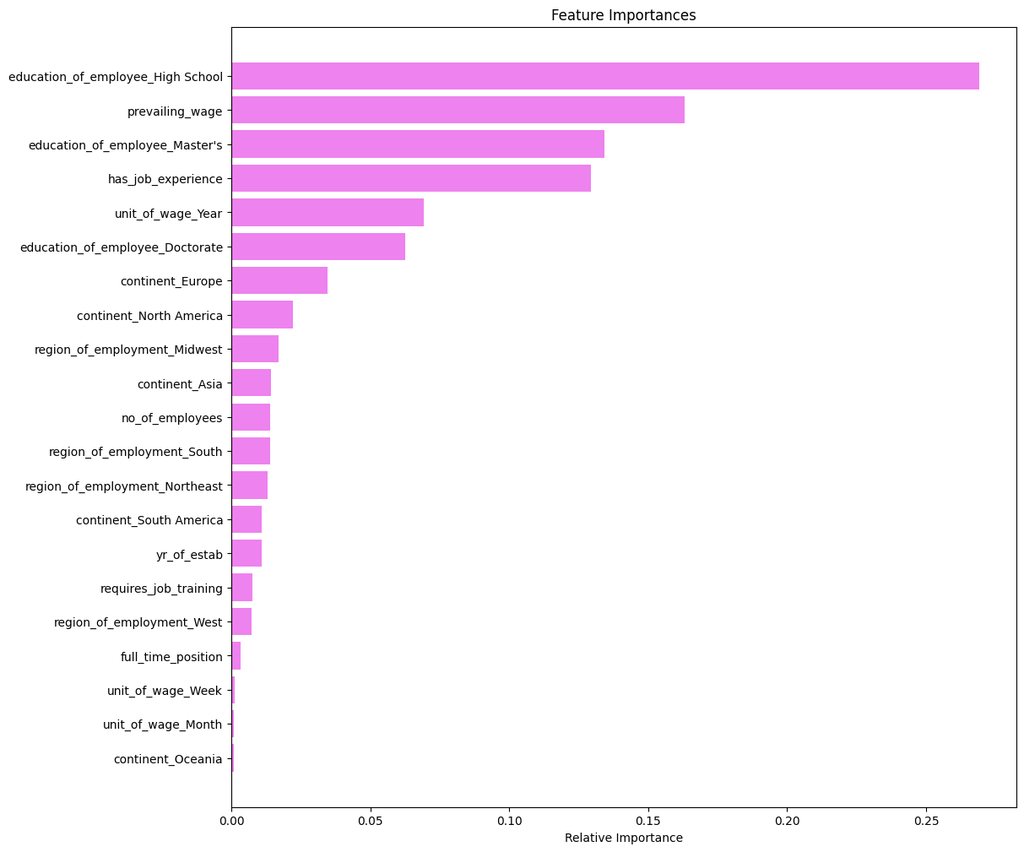

```python
feature_names = X_train.columns
importances = tuned_gbm1.feature_importances_
indices = np.argsort(importances)

plt.figure(figsize=(12, 12))
plt.title("Feature Importances")
plt.barh(range(len(indices)), importances[indices], color="violet", align="center")
plt.yticks(range(len(indices)), [feature_names[i] for i in indices])
plt.xlabel("Relative Importance")
plt.show()
```

**Observations:**

# **Actionable Insights and Recommendations**

- The Gradient Boosting model demonstrates strong performance with high recall metric (93%), ensuring that most qualified applicants are correctly identified.
- The model is very good at identifying qualified applicants, but it also approves some unqualified ones.
- True Positive (TP): 3183 applicants were predicted as Certified , and they would be really Certified.
- True Negative (TN): 441 applicants were predicted as Denied, and they would be really Denied.
- False Negative (FN): 221 applicants were predicted as Denied, but in truth they would be Certified. These are lost good canditates.
- False Positive (FP): 1251 applicants were predicted as Certified, but in truth they would be Denied. These are wrong/risk approvals.

**Top drivers:**

- The education_of_employee_High School feature has the strongest influence.
- The prevailing_wage feature (salary) matters a lot as well.
- The education_of_employee_Master's feature, that represent a higher education, increases approval chances.
- Another important feature is the has_job_experience, it's key.
- Some continents like Europe and North America are listed as important features.

**Actionable Insights:**

- Based on the top drivers mentioned above, we can say that **Education** is a major filter.
- Salary is critical, so higher prevailing wages represent higher approval probability.
- Canditates with experience are more likely approved.
- Some regions like Europe and North America are more valued.

**Recommendations:**

- Prioritize applicants with Master's and Doctorate education creating a screening rule based on education level.
- Recommend or encourage employers to offer competitive wages and adjusting salary benchmarks.
- Flag low wages applications for review.
- Give higher priority to experienced applicants.
- Analyze policies or bias in approvals to avoid
- Since the choosen model would approve 1251 applicants instead of deny, would be good to implement a second layer approval like manual review for high-risk approvals.
- The **final recommendation** is implement a hybrid decision system where high probability applications can be approved (auto-approval), medium probability applications need manual review, and low probability applications are auto-rejected.